# Homework 11

Your Name Here

2026-02-13

## Instructions

Answer the following questions and complete the exercises in RMarkdown. Please embed all of your code and push your final work to your repository. Your final lab report should be organized, clean, and run free from errors. Remember, you must remove the `#` for the included code chunks to run. Be sure to add your name to the author header above. For any included plots, make sure they are clearly labeled. You are free to use any plot type that you feel best communicates the results of your analysis.

Make sure to use the formatting conventions of RMarkdown to make your report neat and clean!

## Load the libraries

```r
library(tidyverse)
library(janitor)
library(ggthemes)
```

```r
options(scipen = 999)
```

## Data

For this homework, we are going to use the [Gapminder](https://www.gapminder.org/data/) data on population (pop), GDP per capita (gdp), and life expectancy (lex). These data were downloaded and compiled using the `gapminder_compile.Rmd` script in the data folder.

Let’s focus our attention on data from the past 100 years, between 1925 and 2025.

```r
gapminder <- read_csv("data/gapminder.csv") %>%
  clean_names() %>%
  filter(between(year, 1925, 2025))
```

1. Use the function(s) of your choice to get an idea of the overall structure of the data, including its dimensions, column names, classes, etc.

```r
glimpse(gapminder)
```

```
## Rows: 19,695
## Columns: 5
## $ country <chr> "Afghanistan", "Afghanistan", "Afghanistan", "Afghanistan", "A…
## $ year    <dbl> 1925, 1926, 1927, 1928, 1929, 1930, 1931, 1932, 1933, 1934, 19…
## $ pop     <dbl> 8748779, 8289705, 7854721, 7442562, 7121951, 6888085, 6736411,…
## $ gdp     <dbl> 1113.793, 1127.866, 1142.117, 1156.548, 1171.161, 1185.959, 12…
## $ lex     <dbl> 38.87, 39.01, 39.16, 39.30, 39.44, 39.59, 39.73, 39.88, 40.02,…
```

2. How many countries are represented in this dataset?

```r
gapminder %>%
  distinct(country)
```

```
## # A tibble: 195 × 1
##    country
##    <chr>
##  1 Afghanistan
##  2 Angola
##  3 Albania
##  4 Andorra
##  5 UAE
##  6 Argentina
##  7 Armenia
##  8 Antigua and Barbuda
##  9 Australia
## 10 Austria
## # ℹ 185 more rows
```

**195 countries** are represented in the data.  
3. Which five countries have had the largest absolute population growth between 1925-2025? Show this as a table.

```r
gapminder %>%
  select(country, year, pop) %>%
  pivot_wider(
    names_from = year,
    values_from = pop,
    names_prefix = "pop_"
  ) %>%
  group_by(country) %>%
  summarise(absolute_pop_growth = pop_2025 - pop_1925) %>%
  arrange(desc(absolute_pop_growth)) %>%
  filter(absolute_pop_growth >= 231082046)
```

```
## # A tibble: 5 × 2
##   country   absolute_pop_growth
##   <chr>                   <dbl>
## 1 India              1159459506
## 2 China               942354621
## 3 Indonesia           236035973
## 4 Pakistan            232594746
## 5 USA                 231082046
```

The five countries have had the largest absolute population growth between 1925-2025 are **India, China, Indonesia, Pakistan, and the USA**.  
4. Make a plot that shows population growth over time for the top country you found in question #3.

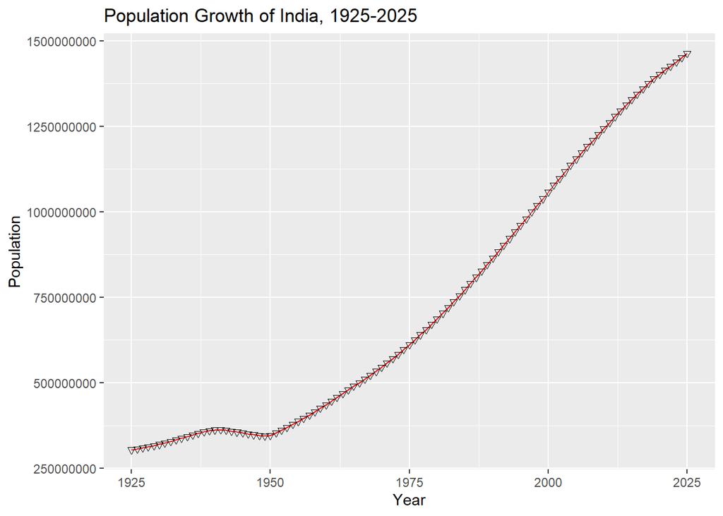

```r
gapminder %>%
  select(country, year, pop) %>%
  filter(country == "India") %>%
  ggplot(aes(x = year, y = pop)) +
  geom_line(color = "red") +
  geom_point(shape = 6) +
  labs(
    title = "Population Growth of India, 1925-2025",
    x = "Year",
    y = "Population"
  )
```

5. Has global life expectancy changed between 1925 and 2025? Show the min, median, mean, and max for all countries (combined) in the dataset.

```r
gapminder %>%
  select(country, lex) %>%
  group_by(country) %>%
  summarise(
    min_lex = min(lex, na.rm = TRUE),
    median_lex = median(lex, na.rm = TRUE),
    mean_lex = mean(lex, na.rm = TRUE),
    max_lex = max(lex, na.rm = TRUE)
  )
```

```
## # A tibble: 195 × 5
##    country             min_lex median_lex mean_lex max_lex
##    <chr>                 <dbl>      <dbl>    <dbl>   <dbl>
##  1 Afghanistan            38.9       46.3     49.0    65.1
##  2 Albania                32.8       70.2     63.1    79.7
##  3 Algeria                32.4       56.9     58.7    77.5
##  4 Andorra                74.6       78.8     78.9    83.2
##  5 Angola                 36.8       47.5     48.9    66.3
##  6 Antigua and Barbuda    36.9       70.2     65.3    77.3
##  7 Argentina              53.7       67.7     67.9    77.6
##  8 Armenia                17.8       67.9     59.8    76.9
##  9 Australia              63.2       72.5     73.9    84.3
## 10 Austria                31.4       71.4     70.1    83.2
## # ℹ 185 more rows
```

6. Make a plot that shows the distribution of life expectancy for all countries in 1925 and 2025 (try using `geom_density`). What do you notice about the shift in life expectancy over time?

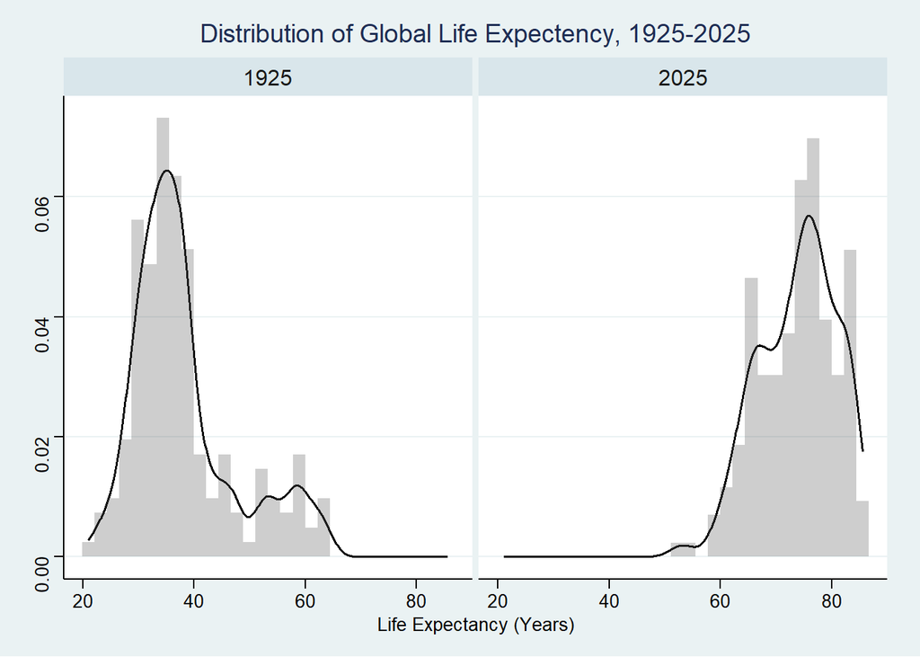

```r
p <- gapminder %>%
  select(country, year, lex) %>%
  filter(year %in% c(1925, 2025)) %>%
  ggplot(aes(x=lex))+
  geom_density() +
  geom_histogram(aes(y = after_stat(density)), alpha = 0.3) +
  facet_wrap(~year, ncol = 2) +
  labs(
    title = "Distribution of Global Life Expectency, 1925-2025",
    x = "Life Expectancy (Years)",
    y = NULL
  )
p + theme_stata()
```

Over time, the distribution of life expectancy shifted from the younger 20-40 years to the much older 60-80 years.  
7. We are interested in the relationship between per capita GDP and life expectancy; i.e. does having more money help you live longer in 2025? Show this as a plot. (Suggestion! Remove Monaco as an extreme outlier.)

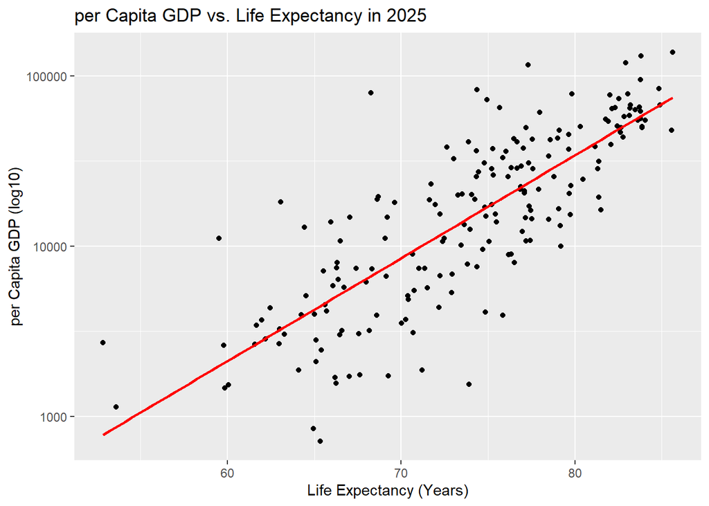

```r
gapminder %>%
  filter(country != "Monaco", year == 2025) %>%
  ggplot(aes(x = lex, y = gdp)) +
  geom_point() +
  geom_smooth(method = "lm", se = FALSE, color = "red") +
  scale_y_log10() +
  labs(
    title = "per Capita GDP vs. Life Expectancy in 2025",
    x = "Life Expectancy (Years)",
    y = "per Capita GDP (log10)"
  )
```

Generally, having more money helped you live longer in 2025.  
8. Which five countries have had the highest absolute GDP per capita growth over the past 50 years? Show this as a table. (Suggestion! Remove Monaco as an extreme outlier.)

```r
gapminder %>%
  filter(country != "Monaco") %>%
  select(country, year, gdp) %>%
  pivot_wider(
    names_from = year,
    values_from = gdp,
    names_prefix = "gdp_"
  ) %>%
  group_by(country) %>%
  summarise(absolute_gdp_growth = gdp_2025 - gdp_1975) %>%
  arrange(desc(absolute_gdp_growth)) %>%
  filter(absolute_gdp_growth >= 69382.41952)
```

```
## # A tibble: 5 × 2
##   country    absolute_gdp_growth
##   <chr>                    <dbl>
## 1 Singapore              125010.
## 2 Ireland                105071.
## 3 Luxembourg             100088.
## 4 Guyana                  74300.
## 5 Norway                  69382.
```

The five countries that have had the highest absolute GDP per capita growth over the past 50 years are **Singapore, Ireland, Luxembourg, Guyana, and Norway**.  
9. How does per capita GDP growth compare between these same five countries over the past 50 years? Show this as a plot.

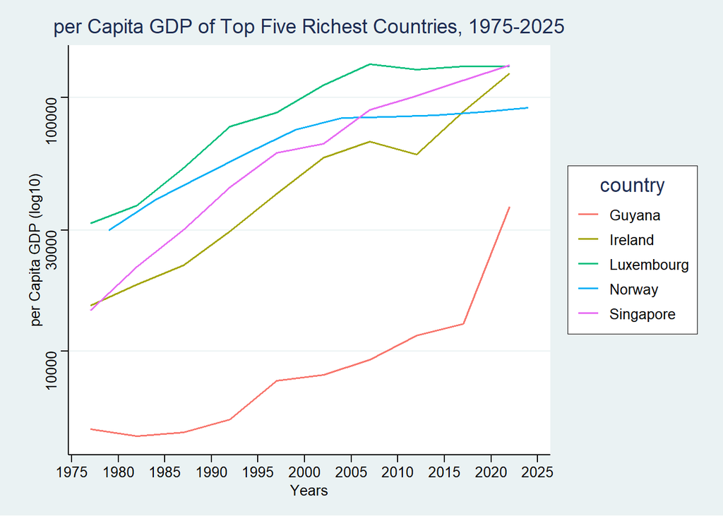

```r
p <- gapminder %>%
  filter(country == c("Singapore", "Ireland", "Luxembourg", "Guyana", "Norway"), year >= 1975) %>%
  ggplot(aes(x = year, y = gdp, color = country)) +
  geom_line() +
  scale_y_log10() +
  scale_x_continuous(breaks = seq(1975, 2025, by = 5), minor_breaks = NULL) +
  labs(
    title = "per Capita GDP of Top Five Richest Countries, 1975-2025",
    x = "Years",
    y = "per Capita GDP (log10)"
  )
p + theme_stata()+
  theme(legend.position = "right")
```

10. Do one analysis of your choice that includes a table and plot as outputs.

```r
gapminder %>%
  select(country, year, lex) %>%
  pivot_wider(
    names_from = year,
    values_from = lex,
    names_prefix = "lex_"
  ) %>%
  group_by(country) %>%
  summarise(absolute_lex_change = lex_2025 - lex_1975) %>%
  arrange(desc(absolute_lex_change)) %>%
  filter(absolute_lex_change >= 25.13)
```

```
## # A tibble: 5 × 2
##   country    absolute_lex_change
##   <chr>                    <dbl>
## 1 Cambodia                  46.4
## 2 Maldives                  28.8
## 3 Ethiopia                  27.5
## 4 Bangladesh                25.7
## 5 Lao                       25.1
```

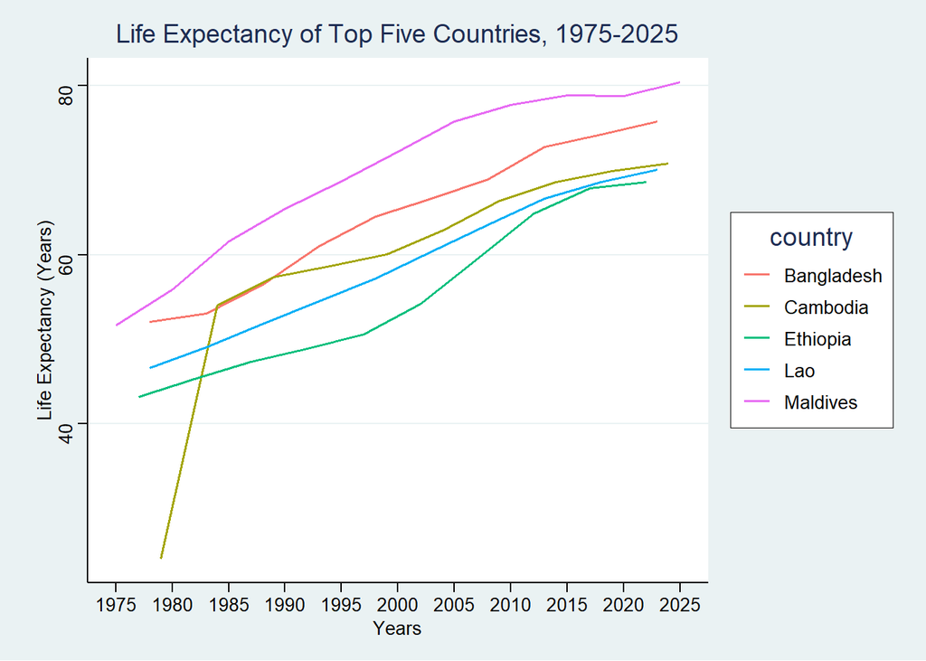

```r
p <- gapminder %>%
  filter(country == c("Cambodia", "Maldives", "Ethiopia", "Bangladesh", "Lao"), year >= 1975) %>%
  ggplot(aes(x = year, y = lex, color = country)) +
  geom_line() +
  scale_x_continuous(breaks = seq(1975, 2025, by = 5), minor_breaks = NULL) +
  labs(
    title = "Life Expectancy of Top Five Countries, 1975-2025",
    x = "Years",
    y = "Life Expectancy (Years)"
  )
p + theme_stata()+
  theme(legend.position = "right")
```

The five countries that have had the highest raise of life expectancy over the past 50 years are **Cambodia, Maldives, Ethiopia, Bangladesh, and Lao**.

## Knit and Upload

Please knit your work as an .html file and upload to Canvas. Homework is due before the start of the next lab. No late work is accepted. Make sure to use the formatting conventions of RMarkdown to make your report neat and clean!